# Reproducible Research: Peer Assessment 2

### Nguyen Toan 22nd Sep. 2014

# Storm Data Analysis

## Synopsis

The purpose of this report is to explore the NOAA Storm Database and answer the following questions about severe weather events:

- Across the United States, which types of events (as indicated in the EVTYPE variable) are most harmful with respect to population health?
- Across the United States, which types of events have the greatest economic consequences?

### Getting and Loading the Data

We get the dataset from the Coursera “Reproducible Research” course [file repository](https://d396qusza40orc.cloudfront.net/repdata%2Fdata%2FStormData.csv.bz2). This dataset is stored in bzip archive format, so we also have to extract it.

```r
download.file(url="http://d396qusza40orc.cloudfront.net/repdata%2Fdata%2FStormData.csv.bz2",
              destfile="StormData.csv.bz2",
              method="curl") # for MacOS
system("bzip2 -d StormData.csv.bz2")
```

### Data Preprocessing

Load the data into memory and grabs necessary columns only such that EVTYPE and those relating to event date, fatalities, injuries, property damage.

```r
storm.df <- read.csv("StormData.csv",
                     stringsAsFactors = FALSE)[c(2, 8, 23:28)]
```

Next we calculate the total damage including property and crop damage for each event as follows:

- property damage = PROPDMG * PROPDMGEXP
- crop damage = CROPDMG * CROPDMGEXP

However, there are some special values in PROPDMGEXP and CROPDMGEXP that we need to convert into numeric format in advance.

```r
unique(storm.df$PROPDMGEXP)
```

[1] “K” “M” “” “B” “m” “+” “0” “5” “6” “?” “4” “2” “3” “h” “7” “H” “-” [18] “1” “8”

```r
unique(storm.df$CROPDMGEXP)
```

[1] “” “M” “K” “m” “B” “?” “0” “k” “2”

From the [Storm Data Documentation](https://d396qusza40orc.cloudfront.net/repdata%2Fpeer2_doc%2Fpd01016005curr.pdf): * “K”, “k” mean thousands * “M”, “m” means millions * “B” means billions

Other values are not documented so we assume they are zeros. Hence we calculate the total damage as follow:

```r
# function converting symbol into numeric value
convert <- function(x) {
  switch(EXPR=x,
         K=10^3, k=10^3,
         M=10^6, m=10^6,
         B=10^9, 0)
}

storm.df$PROPDMGEXP <- as.numeric(lapply(storm.df$PROPDMGEXP, FUN=convert))
storm.df$CROPDMGEXP <- as.numeric(lapply(storm.df$CROPDMGEXP, FUN=convert))
storm.df$PROPDMG <- as.numeric(storm.df$PROPDMG)
storm.df$CROPDMG <- as.numeric(storm.df$CROPDMG)
storm.df$TOTALPROPDMG <- storm.df$PROPDMG * storm.df$PROPDMGEXP +
                         storm.df$CROPDMG * storm.df$CROPDMGEXP
```

Next we calculate the total damage for each event in EVTYPE

```r
storm.sum.df <- aggregate(storm.df[, c(3,4,9)],
                          by=list(storm.df$EVTYPE),
                          FUN=sum)
names(storm.sum.df) <- c("EVTYPE","FATALITIES","INJURIES","TOTALPROPDMG")
```

Then we find top 10 event types.

```r
fatalities.top10 <- storm.sum.df[order(storm.sum.df$FATALITIES, decreasing = TRUE), ][1:10, c("EVTYPE","FATALITIES")]
injuries.top10 <- storm.sum.df[order(storm.sum.df$INJURIES, decreasing = TRUE), ][1:10, c("EVTYPE","INJURIES")]
totalpropdmg.top10 <- storm.sum.df[order(storm.sum.df$TOTALPROPDMG, decreasing = TRUE), ][1:10, c("EVTYPE","TOTALPROPDMG")]

fatalities.top10$EVTYPE <- factor(fatalities.top10$EVTYPE,
                                  levels=fatalities.top10$EVTYPE)
injuries.top10$EVTYPE <- factor(injuries.top10$EVTYPE,
                                  levels=injuries.top10$EVTYPE)
totalpropdmg.top10$EVTYPE <- factor(totalpropdmg.top10$EVTYPE,
                                  levels=totalpropdmg.top10$EVTYPE)
```

### Results

#### Events that are most harmful with respect to population health

Below is the graphs of top 10 most harmful event types in terms of the total fatalities and injuries respectively. We can see that tornadoes cause the most fatalities and injuries.

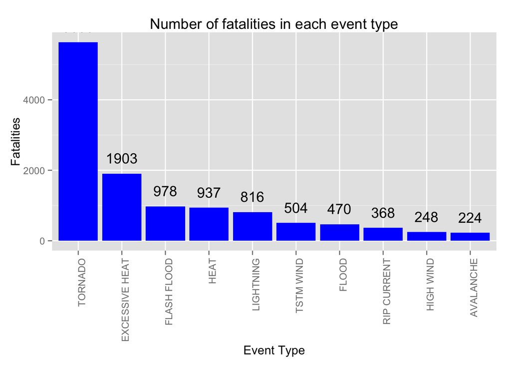

```r
ggplot(fatalities.top10, aes(x=EVTYPE, y=FATALITIES)) +
  geom_bar(stat="identity", fill="blue", las=3) +
  theme(axis.text.x=element_text(angle=90, hjust=1)) +
  xlab("Event Type") +
  ylab("Fatalities") +
  ggtitle("Number of fatalities in each event type") +
  geom_text(aes(x=EVTYPE, y=FATALITIES, label=FATALITIES, hjust=0.5, vjust=-1))
```

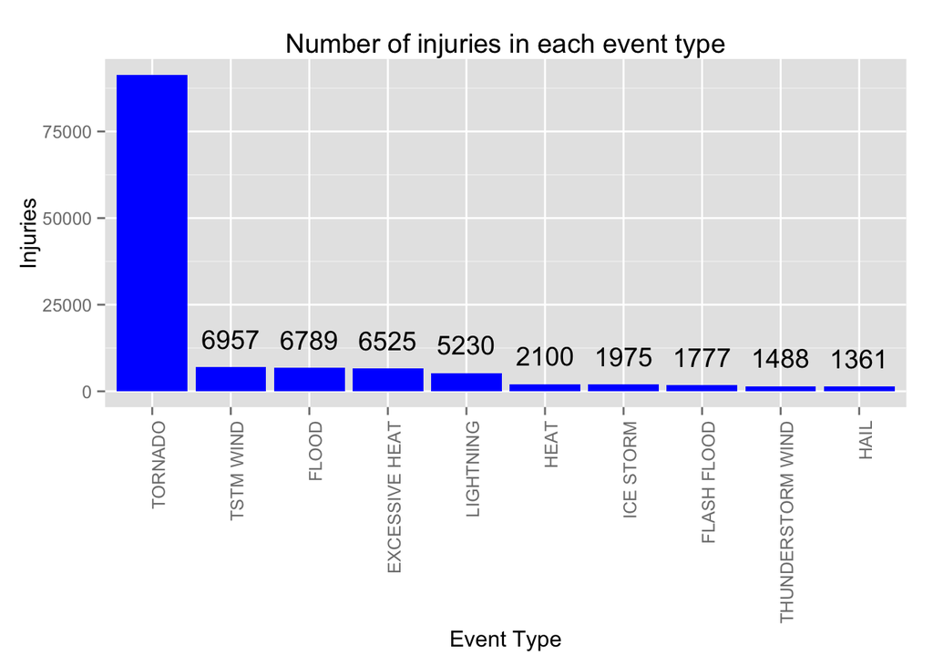

```r
ggplot(injuries.top10, aes(x=EVTYPE, y=INJURIES)) +
  geom_bar(stat="identity", fill="blue", las=3) +
  theme(axis.text.x=element_text(angle=90, hjust=1)) +
  xlab("Event Type") +
  ylab("Injuries") +
  ggtitle("Number of injuries in each event type") +
  geom_text(aes(x=EVTYPE, y=INJURIES, label=INJURIES, hjust=0.5, vjust=-1))
```

### Events that have the greatest economic consequences

Below is the graph of top 10 events that had the greatest total property damage (including crop damage). Flooding, hurricanes/typhoons, tornadoes and storm surges are the most costly event types to the economy.

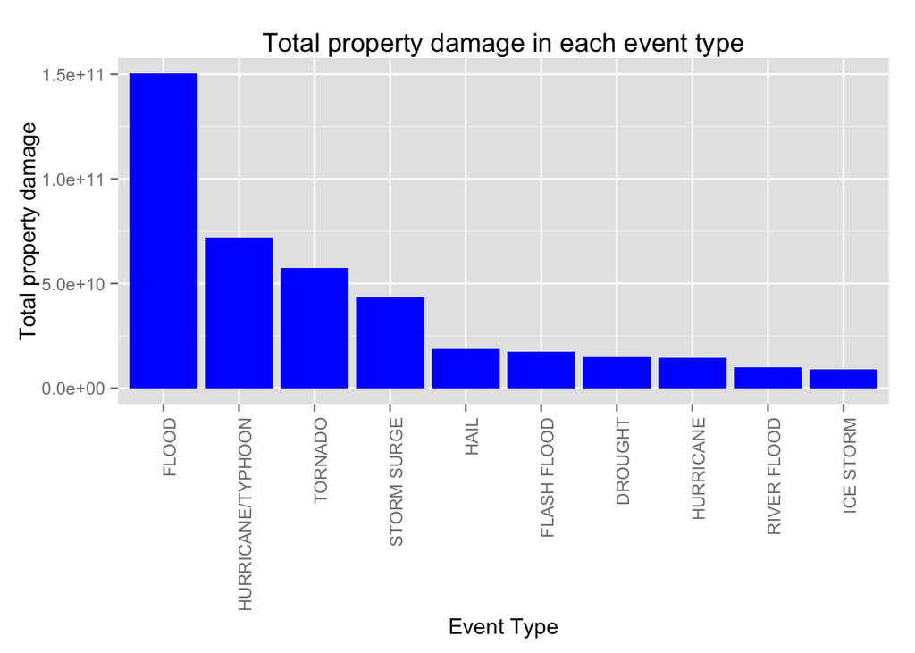

```r
ggplot(totalpropdmg.top10, aes(x=EVTYPE, y=TOTALPROPDMG)) +
  geom_bar(stat="identity", fill="blue", las=3) +
  theme(axis.text.x=element_text(angle=90, hjust=1)) +
  xlab("Event Type") +
  ylab("Total property damage") +
  ggtitle("Total property damage in each event type")
```